# Expression array normalization and analysis

Lindsay A Holden

June 6, 2017

## Outline

Initial normalization based on Mattick Lab protocol, see  
http://matticklab.com/index.php?title=Single_channel_analysis_of_Agilent_microarray_data_with_Limma

1. normalize arrays
   1. load libraries, target file, annotations, and gene list
   2. load data into an RGList object
   3. assign spot types and set the status of each spot on the array
   4. subract background fluorescence
   5. normalize between arrays
   6. average replicate spots
2. applying linear model
   1. create a design matrix for linear modeling function
   2. apply intensity values to lmFit (linear model)
   3. create contrast matrix for your comparison of interest
   4. apply contrast matrix to modeled data & compute statistics
   5. output stats
   6. annotate output

## Reading Microarray Data

### Load libraries

Load the libraries you’ll be using.

```r
library(limma)
```

### Load target file

Load your target file containing SampleNumber, FileName, and Condition data. Make sure to include full filepath. In my target file each row is one sample and each column is one descriptor.

```r
targets <- readTargets(file = "targets.txt")
names(targets) ## to view the column names
```

```
## [1] "SampleNumber" "FileName"     "Condition"    "sex"
## [5] "strain"       "time"         "treatment"    "run"
```

### Load annotations

These annotations are what come from Agilent. Currently, they are Zv9 (danRer7) and should be queried against more updated releases of RefGene, ENTREZ, ENSEMBL, etc.

```r
annotations <- read.csv("AllAnnotations.csv")
names(annotations) ## to view the column names
```

```
##  [1] "ProbeID"            "PrimaryAccession"   "RefSeqAccession"
##  [4] "GenbankAccession"   "UniGeneID"          "EntrezGeneID"
##  [7] "GeneSymbol"         "GeneName"           "EnsemblID"
## [10] "TIGRID"             "GO"                 "Description"
## [13] "GenomicCoordinates" "Cytoband"
```

### Load genelist

The genelist is pretty much the same thing as annotations and also come from Agilent. Currently, they are Zv9 (danRer7) and should be queried against more updated releases of RefGene, ENTREZ, ENSEMBL, etc.

```r
genelist <- read.delim2("E:/LINDSAY/expression arrays/all arrays/genelist_withcontrols.txt")
names(genelist) ## to view the column names
```

```
## [1] "ProbeID"     "TargetID"    "GeneSymbol"  "GeneName"    "Accessions"
## [6] "Description"
```

### Image-derived spot quality weights

First, define which spots you want to weight. Do this by writing a function that weights strongly positive spots as 1 and flagged spots as 0. We will apply this when we load the array files.

```r
myFlagFun <- function(x) {
#Weight only strongly positive spots 1, everything else 0
present <- x$gIsPosAndSignif == 1
probe <- x$ControlType == 0
manual <- x$IsManualFlag == 0
strong <- x$gIsWellAboveBG == 1
y <- as.numeric(present & probe & manual & strong)
#Weight flagged spots 0
sat <- x$gIsSaturated == 0
xdr <- x$gIsLowPMTScaledUp == 0
featureOL1 <- x$gIsFeatNonUnifOL == 0
featureOL2 <- x$gIsFeatPopnOL == 0
flagged <- (sat & xdr & featureOL1 & featureOL2)
flagged <- grep(FALSE, flagged)
good <- grep(TRUE, y==1)
flagged <- intersect(flagged, good)
y[flagged] <- 0
y
}
```

### Load array files

Using read.maimages, load extracted array files (txt output from Agilent’s Feature Extraction Program) as an EListRaw from a set of one-color files.

```r
a <- read.maimages(targets,
                   source = "agilent", ## same as "agilent.median" other option is "agilent.mean"
                   green.only = TRUE,
                   wt.fun = myFlagFun)
```

This takes a minute or two (depending on how many files you have to load). Then check how many arrays loaded.

```r
dim(a)
```

```
## [1] 45220   162
```

```r
colnames(a)
```

```
##   [1] "AB_00hr_cont_F"  "AB_00hr_cont_H"  "AB_00hr_cont_I"
##   [4] "AB_00hr_cont_K"  "AB_00hr_cont_M"  "AB_00hr_cont_N"
##   [7] "AB_06hr_PCB_F"   "AB_06hr_PCB_G"   "AB_06hr_PCB_I"
##  [10] "AB_06hr_PCB_K"   "AB_06hr_PCB_M"   "AB_06hr_PCB_N"
##  [13] "AB_06hr_veh_G"   "AB_06hr_veh_H"   "AB_06hr_veh_I"
##  [16] "AB_06hr_veh_K"   "AB_06hr_veh_L"   "AB_06hr_veh_M"
##  [19] "AB_12hr_PCB_F"   "AB_12hr_PCB_G"   "AB_12hr_PCB_I"
##  [22] "AB_12hr_PCB_K"   "AB_12hr_PCB_L"   "AB_12hr_PCB_M"
##  [25] "AB_12hr_veh_F"   "AB_12hr_veh_I"   "AB_12hr_veh_K"
##  [28] "AB_12hr_veh_L"   "AB_12hr_veh_M"   "AB_12hr_veh_N"
##  [31] "AB_24hr_PCB_F"   "AB_24hr_PCB_G"   "AB_24hr_PCB_I"
##  [34] "AB_24hr_PCB_J"   "AB_24hr_PCB_K"   "AB_24hr_PCB_L"
##  [37] "AB_24hr_veh_F"   "AB_24hr_veh_G"   "AB_24hr_veh_H"
##  [40] "AB_24hr_veh_I"   "AB_24hr_veh_J"   "AB_24hr_veh_M"
##  [43] "AB_48hr_PCB_F"   "AB_48hr_PCB_I"   "AB_48hr_PCB_K"
```

[output cut: 39 more lines]

### Reading probe annotation

a$genes had a ProbeID vector, but it only contains numbers at this point. We want to add human-readable probe IDs. These are found in the .gal file provided in the Agilent design file (026437). I dragged and dropped the .gal file into my directory.

```r
a$genes <- readGAL(galfile = "026437_D_20140627.gal",
                   path = "C:/Users/holdenl/Documents/ExpressionArrays")
dim(a$genes)
```

```
## [1] 96700    10
```

```r
names(a$genes)
```

```
##  [1] "Block"       "Column"      "Row"         "Name"        "ID"
##  [6] "RefNumber"   "ControlType" "GeneName"    "TopHit"      "Description"
```

### Printer layout

This is already loaded into our EListRaw. We have commerically produce Agilent arrays, so this shouldn’t really matter, but we’ll look at it anyway.

```r
names(a$printer)
```

```
## [1] "ngrid.r" "ngrid.c" "nspot.r" "nspot.c"
```

### Assign spot types

The SpotType file allows you to identify spots when visualizing sampels on plots to assess sample quality. First load the file, see what it contains, then assign the status of each spot on the array.

```r
spottypes <- readSpotTypes(file = "SpotType.txt",
                           sep = "\t")
names(spottypes)
```

```
## [1] "SpotType"    "ControlType" "Name"        "Color"
```

```r
a$genes$Status <- controlStatus(spottypes, a)
```

```
## Matching patterns for: ControlType Name
## Found 93456 Probe
## Found 40 PositiveControlDCP
## Found 288 PositiveControlETG
## Found 272 PositiveControlRC
## Found 284 NegativeControl
## Found 668 SpikeinControl
## Found 84 eQC
## Found 32 GEBrightCorner
## Found 1576 DarkCorner
## Setting attributes: values Color
```

## Quality Assessment

### Visualize on an MA-plot

For single channel data objects, a between-array MD-plot is produced. An articifial array is produced by averaging all the arrays other than the array specified. A mean-difference plot is then producing from the specified array and the artificial array. Note that this procedure reduces to an ordinary mean-difference plot when there are just two arrays total.

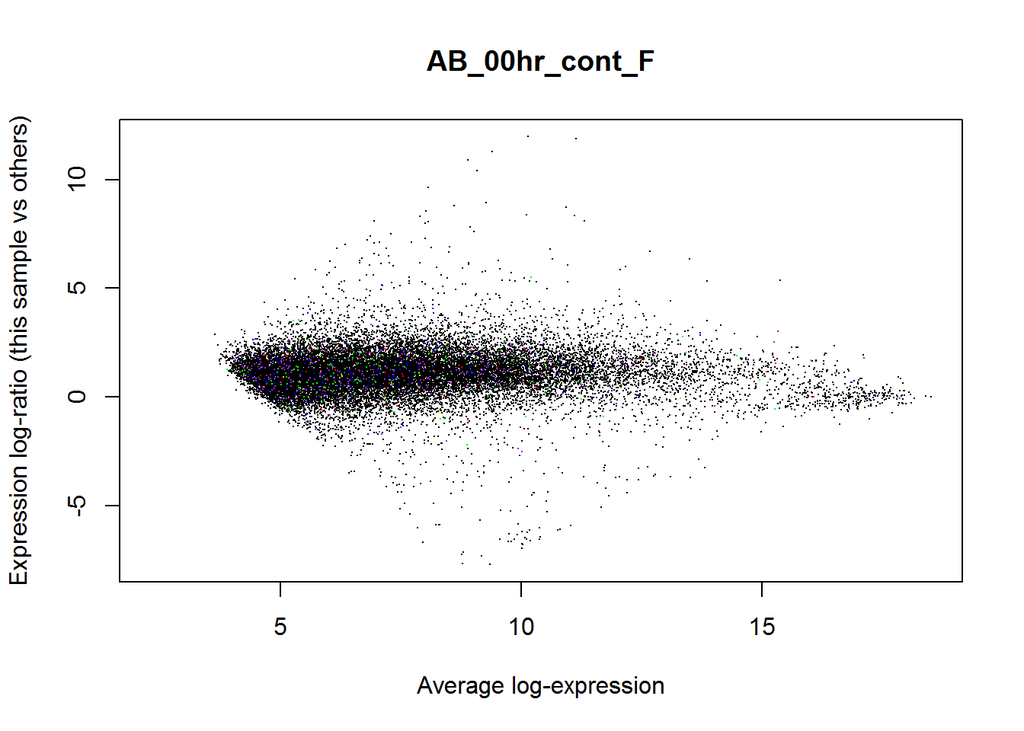

```r
plotMD(a, legend = FALSE, cex = 0.1) ## uses the first array file vs all others
```

```r
plotMA3by2(a, path = "C:/Users/holdenl/Documents/ExpressionArrays/raw_MAplots", cex = 0.1) ## all arrays individually vs all others...will take a wee bit and prints out png files
```

### Visualize background intensity boxplots

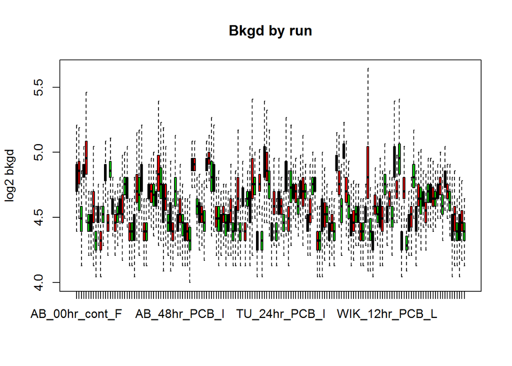

```r
boxplot(data.frame(log2(a$Eb)), col = c(1,2,3), group = targets$run, outline = FALSE, main = "Bkgd by run", ylab = "log2 bkgd")
```

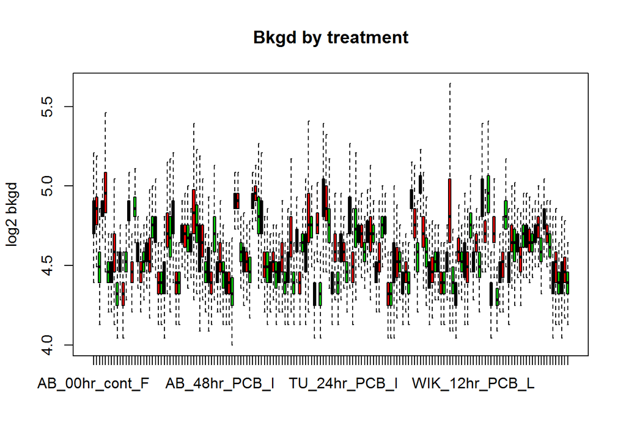

```r
boxplot(data.frame(log2(a$Eb)), col = c(1,2,3), group = targets$treatment, outline = FALSE, main = "Bkgd by treatment", ylab = "log2 bkgd")
```

### Spatial heterogeneity

Don’t think we really have to worry about this, because we have commercially produced arrays, but this shows the spatial hetergenetiy of the background intensities for each array.

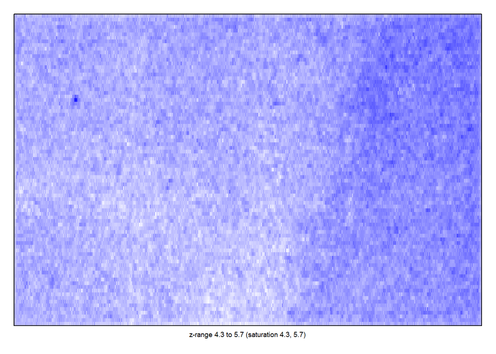

```r
imageplot(log2(a$Eb[,1]), a$printer)
```

## Pre-processing Data

### Background correction

There is a dearth of literature on what is the correct way to background normalize arrays. Default is to subtract the background intensity from the foreground intensity at each spot. the backgroundCorrect function has several options. First you define your EListRaw, then choose a method, whether or not to add an offset (if you cannot have negative corrected intensities), add your printer info, and clarify the method if you are using normexp. The options for methods include “auto”, “none”, “subtract”, “half”, “minimum”, “movingmin”, “edwards” or “normexp”.  
auto == subtract  
none == none  
subtract = the background intensities are subtracted from the foreground intensities  
half = any intensity which is less than 0.5 after background subtraction is reset to be equal to 0.5  
minimum = any intensity which is zero or negative after background subtraction is set equal to half the minimum of the positive corrected intensities for that array  
movingmin = the background estimates are replaced with the minimums of the backgrounds of the spot and its eight neighbors, i.e., the background is replaced by a moving minimum of 3x3 grids of spots  
edwards = a log-linear interpolation method is used to adjust lower intensities  
normexp = a convolution of normal and exponential distributions is fitted to the foreground intensities using the background intensities as a covariate, and the expected signal given the observed foreground becomes the corrected intensity. This results in a smooth monotonic transformation of the background subtracted intensities such that all the corrected intensities are positive  
The normexp function uses maximum likelihood estimation to fit the normexp model to background-corrected intensities. The model assumes that the observed intensities are the sum of background and signal components, the background being normal and the signal being exponential distributed. It also has it’s own parameters to choose from:  
saddle = the saddle-point approximation to maximum likelihood  
mle = exact maximum likelihood  
rma = the background correction algorithm from the RMA-algorithm for Affymetrix microarray data as implemented in the affy package  
rma75 = the RMA-75 method from McGee and Chen (2006)  
In practice “mle” performs well and is nearly as fast as “saddle”, but “saddle” is the default for backward compatibility.  
I need to choose which background correction algorythm to apply to my dataset. Let’s start by trying them all!

```r
b.none <- backgroundCorrect(RG = a,  method = "none", offset = 0, printer = a$printer)
b.subtract <- backgroundCorrect(RG = a, method = "subtract", offset = 0, printer = a$printer)
b.half <- backgroundCorrect(RG = a,  method = "half", offset = 0, printer = a$printer)
b.minimum <- backgroundCorrect(RG = a,  method = "minimum", offset = 0, printer = a$printer)
b.movingmin <- backgroundCorrect(RG = a,  method = "movingmin", offset = 0, printer = a$printer)
b.edwards <- backgroundCorrect(RG = a,  method = "edwards", offset = 0, printer = a$printer)
b.normexp.saddle <- backgroundCorrect(RG = a,  method = "normexp", offset = 0, printer = a$printer, normexp.method = "saddle", verbose = FALSE)
b.normexp.mle <- backgroundCorrect(RG = a,  method = "normexp", offset = 0, printer = a$printer, normexp.method = "mle", verbose = FALSE)
```

And we can then plot them all side by side.

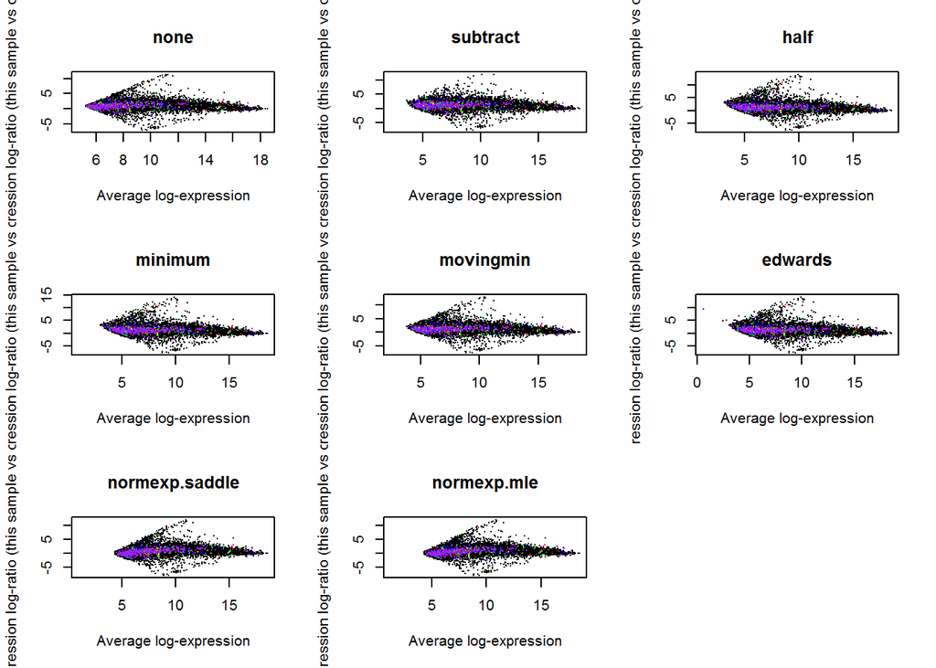

```r
par(mfrow=c(3,3))
plotMD(b.none, cex = 0.1, legend = FALSE, main = "none")
plotMD(b.subtract, cex = 0.1, legend = FALSE, main = "subtract")
plotMD(b.half, cex = 0.1, legend = FALSE, main = "half")
plotMD(b.minimum, cex = 0.1, legend = FALSE, main = "minimum")
plotMD(b.movingmin, cex = 0.1, legend = FALSE, main = "movingmin")
plotMD(b.edwards, cex = 0.1, legend = FALSE, main = "edwards")
plotMD(b.normexp.saddle, cex = 0.1, legend = FALSE, main = "normexp.saddle")
plotMD(b.normexp.mle, cex = 0.1, legend = FALSE, main = "normexp.mle")
```

Background correction methods “subtract” and “movingmin” both results w/ NaNs produced, which I believe means that they produce negative values. Can’t really tell the difference at this stage…